# Cyclistic_Casestudy

## Google Data Analytics: Capstone Project

## Cyclistic bike-share analysis - Link

[figure not shown]

Case study - How does a bike-share navigate speedy success?  
Objective - Through this Project I apply the knowledge which I gained through this [Google Data Analytics](https://www.coursera.org/professional-certificates/google-data-analytics) Course.  
Author - Manoj Kumar S | [LinkedIn](https://www.linkedin.com/in/manojkumarsudalai/) | [Credly](https://www.credly.com/users/manojkumarsudalai) | [HackerRank](https://www.hackerrank.com/profile/s_manochkumar)  
Date - 18-08-2024

### Summary of the Project - Case Study

The Cyclistic is a fictional bike share company in Chicago. The director of marketing believes the company’s future success depends on maximizing the number of annual memberships. for this we need to design a new strategy to increase the number of annual memberships. We need to analyze and visualize the analysis.

##### Stakeholder

Lily Moreno: The director of marketing and your manager.  
Cyclistic Executive Team: Decision-makers for approving marketing strategies  
Cyclistic Marketing Analytics Team

##### About the company

Company Started Year: In 2016  
No.of Bicycles : 5,824 bicycles  
No.of Stations : 692 stations  
Mode of Usage : Unlocked from one station and returned to any other station in the system anytime  
Pricing Plans : Single-ride passes - Full-day passes - Annual memberships  
Cyclistic members : Customers who purchase annual memberships  
Aimed : Converting casual riders into Annual members

### Deliverables

This report with the following deliverables:

1. A clear statement of the business task
2. A description of all data sources used
3. Documentation of any cleaning or manipulation of data
4. A summary of your analysis
5. Supporting visualizations and key findings
6. Your top three recommendations based on your analysis

### Objective 1. A clear statement of the business task

1. How do annual members and casual riders use Cyclistic bikes differently?
2. Why would casual riders buy Cyclistic annual memberships?
3. How can Cyclistic use digital media to influence casual riders to become members?

Tasks Solution Summary

1. Need to find the cycle usage pattern of the riders and members in daily, weekly, monthly and Yearly. What are the popular routes they are using, what is the duration of usage.
2. By Filtering out the reason or factor which let a rider to become a member.
3. Based on the analysis we use the effective strategy for the digital media influence

### Objective 2. A description of all data sources used

For the purposes of this case study, We are using the public data to explore how different customer types are using Cyclistic bikes.

**Data Source:** Downloaded the Multiple CSV(Comma Seperated Value) file from here - [The previous 12 months of Cyclistic trip data](https://divvy-tripdata.s3.amazonaws.com/index.html)

**License:** The data has been made available by Motivate International Inc. under this [license](https://www.divvybikes.com/data-license-agreement).

### Objective 3. Documentation of any cleaning or manipulation of data

The data of 2019 is going to be used for the analysis.

The Filename:  
1. Divvy_Trips_2019_Q1.csv  
2. Divvy_Trips_2019_Q2.csv  
3. Divvy_Trips_2019_Q3.csv  
4. Divvy_Trips_2019_Q4.csv

```python
#To review the Data structure and columns
import pandas as pd #using pandas for data cleaning, manipulation

dfQ1 = pd.read_csv('C:\\Users\\M13J10\\Downloads\\CaseStudy\\cycledata\\Divvy_Trips_2019_Q1.csv')
dfQ2 = pd.read_csv('C:\\Users\\M13J10\\Downloads\\CaseStudy\\cycledata\\Divvy_Trips_2019_Q2.csv')
dfQ3 = pd.read_csv('C:\\Users\\M13J10\\Downloads\\CaseStudy\\cycledata\\Divvy_Trips_2019_Q3.csv')
dfQ4 = pd.read_csv('C:\\Users\\M13J10\\Downloads\\CaseStudy\\cycledata\\Divvy_Trips_2019_Q4.csv')
print('Data Imported Successfully!')
```

```
Data Imported Successfully!
```

We imported the data from the 4 csv files and created a 4 data frame to make this a single data frame we are concating the data frames before that we need to confirm whether all the columns of the dataframes are same or not

```python
print('Q1: ',dfQ1.columns)
print('Q2: ',dfQ2.columns)
print('Q3: ',dfQ3.columns)
print('Q4: ',dfQ4.columns)
```

```
Q1:  Index(['trip_id', 'start_time', 'end_time', 'bikeid', 'tripduration',
       'from_station_id', 'from_station_name', 'to_station_id',
       'to_station_name', 'usertype', 'gender', 'birthyear'],
      dtype='object')
Q2:  Index(['01 - Rental Details Rental ID', '01 - Rental Details Local Start Time',
       '01 - Rental Details Local End Time', '01 - Rental Details Bike ID',
       '01 - Rental Details Duration In Seconds Uncapped',
       '03 - Rental Start Station ID', '03 - Rental Start Station Name',
       '02 - Rental End Station ID', '02 - Rental End Station Name',
       'User Type', 'Member Gender',
       '05 - Member Details Member Birthday Year'],
      dtype='object')
Q3:  Index(['trip_id', 'start_time', 'end_time', 'bikeid', 'tripduration',
       'from_station_id', 'from_station_name', 'to_station_id',
       'to_station_name', 'usertype', 'gender', 'birthyear'],
      dtype='object')
Q4:  Index(['trip_id', 'start_time', 'end_time', 'bikeid', 'tripduration',
       'from_station_id', 'from_station_name', 'to_station_id',
       'to_station_name', 'usertype', 'gender', 'birthyear'],
      dtype='object')
```

Q2 Columns are different than others so converting it to default

```python
dfQ2 = dfQ2.rename(columns = {'01 - Rental Details Rental ID':'trip_id',
                              '01 - Rental Details Local Start Time':'start_time',
                              '01 - Rental Details Local End Time':'end_time',
                              '01 - Rental Details Bike ID':'bikeid',
                              '01 - Rental Details Duration In Seconds Uncapped':'tripduration',
                              '03 - Rental Start Station ID':'from_station_id',
                              '03 - Rental Start Station Name':'from_station_name',
                              '02 - Rental End Station ID':'to_station_id',
                              '02 - Rental End Station Name':'to_station_name',
                              'User Type':'usertype',
                              'Member Gender':'gender',
                              '05 - Member Details Member Birthday Year':'birthyear'})
```

Now all the columns are same for all the dataframe, we can concat the 4 data frames

```python
df = [dfQ1, dfQ2, dfQ3, dfQ4]
df = pd.concat(df)

print('Count of 4 Data Frames:\n',(dfQ1.count())+(dfQ2.count())+(dfQ3.count())+(dfQ4.count()))
```

```
Count of 4 Data Frames:
 trip_id              3818004
start_time           3818004
end_time             3818004
bikeid               3818004
tripduration         3818004
from_station_id      3818004
from_station_name    3818004
to_station_id        3818004
to_station_name      3818004
usertype             3818004
gender               3258798
birthyear            3279253
dtype: int64
```

```python
print('Count of Concated Data Frames:\n',(df.count()))
```

```
Count of Concated Data Frames:
 trip_id              3818004
start_time           3818004
end_time             3818004
bikeid               3818004
tripduration         3818004
from_station_id      3818004
from_station_name    3818004
to_station_id        3818004
to_station_name      3818004
usertype             3818004
gender               3258798
birthyear            3279253
dtype: int64
```

Both Counts are same, now we can work with the single Data frame which have data of entire 2019

##### Data types: Checking the datatypes of the column, if anything is inappropriate that will be convert into the correct datatype.

##### Null Values: Checking the null values, if null values are there fill it with the default values to avoid the discrepancies.

```python
df.info()
```

```
<class 'pandas.core.frame.DataFrame'>
Index: 3818004 entries, 0 to 704053
Data columns (total 12 columns):
 #   Column             Dtype
---  ------             -----
 0   trip_id            int64
 1   start_time         object
 2   end_time           object
 3   bikeid             int64
 4   tripduration       object
 5   from_station_id    int64
 6   from_station_name  object
 7   to_station_id      int64
 8   to_station_name    object
 9   usertype           object
 10  gender             object
 11  birthyear          float64
dtypes: float64(1), int64(4), object(7)
memory usage: 378.7+ MB
```

```python
df.isnull().sum()
```

```
trip_id                   0
start_time                0
end_time                  0
bikeid                    0
tripduration              0
from_station_id           0
from_station_name         0
to_station_id             0
to_station_name           0
usertype                  0
gender               559206
birthyear            538751
dtype: int64
```

##### Null values are there so filling those with default value

##### Converting Datatype for the Time stamp columns (start_time, end_time)

Column Gender and BirthYear having some bank value need to fill it with common value  
Filling "Unknown" in gender column blank cells  
Filling "0" in BirthYear column blank cells

```python
df['gender'] = df['gender'].fillna('unknown')
df['birthyear'] = df['birthyear'].fillna(0)
```

```python
df['start_time'] = pd.to_datetime(df['start_time'])
df['end_time'] = pd.to_datetime(df['end_time'])
df['birthyear'] = df['birthyear'].astype('int')
```

```python
print(df.info(), df.isnull().sum())
```

```
<class 'pandas.core.frame.DataFrame'>
Index: 3818004 entries, 0 to 704053
Data columns (total 12 columns):
 #   Column             Dtype
---  ------             -----
 0   trip_id            int64
 1   start_time         datetime64[ns]
 2   end_time           datetime64[ns]
 3   bikeid             int64
 4   tripduration       object
 5   from_station_id    int64
 6   from_station_name  object
 7   to_station_id      int64
 8   to_station_name    object
 9   usertype           object
 10  gender             object
 11  birthyear          int32
dtypes: datetime64[ns](2), int32(1), int64(4), object(5)
memory usage: 364.1+ MB
None trip_id              0
start_time           0
end_time             0
bikeid               0
tripduration         0
from_station_id      0
from_station_name    0
to_station_id        0
to_station_name      0
usertype             0
gender               0
birthyear            0
dtype: int64
```

#### Now our dataset(df) is clean and proper datatypes for analysis

We Need some other derieved columns for our analysis like,

1. Day of usage,
2. Month of Usage,
3. Age of the User.

```python
df['usage_day'] = df['start_time'].dt.day_name()
df['usage_month'] = df['start_time'].dt.month_name()
df['age'] = 2019 - df['birthyear']
```

```python
df.columns
```

```
Index(['trip_id', 'start_time', 'end_time', 'bikeid', 'tripduration',
       'from_station_id', 'from_station_name', 'to_station_id',
       'to_station_name', 'usertype', 'gender', 'birthyear', 'usage_day',
       'usage_month', 'age'],
      dtype='object')
```

```python
df.head()
```

|  | trip_id | start_time | end_time | bikeid | tripduration | from_station_id | from_station_name | to_station_id | to_station_name | usertype | gender | birthyear | usage_day | usage_month | age |
| --- | --- | --- | --- | --- | --- | --- | --- | --- | --- | --- | --- | --- | --- | --- | --- |
| 0 | 21742443 | 2019-01-01 00:04:37 | 2019-01-01 00:11:07 | 2167 | 390.0 | 199 | Wabash Ave & Grand Ave | 84 | Milwaukee Ave & Grand Ave | Subscriber | Male | 1989 | Tuesday | January | 30 |
| 1 | 21742444 | 2019-01-01 00:08:13 | 2019-01-01 00:15:34 | 4386 | 441.0 | 44 | State St & Randolph St | 624 | Dearborn St & Van Buren St (*) | Subscriber | Female | 1990 | Tuesday | January | 29 |
| 2 | 21742445 | 2019-01-01 00:13:23 | 2019-01-01 00:27:12 | 1524 | 829.0 | 15 | Racine Ave & 18th St | 644 | Western Ave & Fillmore St (*) | Subscriber | Female | 1994 | Tuesday | January | 25 |
| 3 | 21742446 | 2019-01-01 00:13:45 | 2019-01-01 00:43:28 | 252 | 1,783.0 | 123 | California Ave & Milwaukee Ave | 176 | Clark St & Elm St | Subscriber | Male | 1993 | Tuesday | January | 26 |
| 4 | 21742447 | 2019-01-01 00:14:52 | 2019-01-01 00:20:56 | 1170 | 364.0 | 173 | Mies van der Rohe Way & Chicago Ave | 35 | Streeter Dr & Grand Ave | Subscriber | Male | 1994 | Tuesday | January | 25 |

We have all the required column with cleaned data now we can start our next process of the anaylsis analysis

#### Analysis

```python
import matplotlib as plt #importing matplotlib for visuals
print(plt.__version__)
import matplotlib.pyplot as plt
```

```
3.8.2
```

### 1. How do annual members and casual riders use Cyclistic bikes differently?

##### Difference between the ratio riders(Customer) and members(Subscriber)

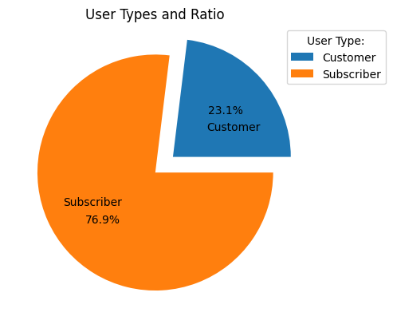

```python
import matplotlib.pyplot as plt

# Grouping and counting the user types
sub_nonsub = df['usertype'].value_counts().sort_values()

# Pie plot
fig, ax = plt.subplots()
ax.pie(sub_nonsub,
       labels=sub_nonsub.index,  # Use the index for labels
       autopct='%1.1f%%',  # Display percentages on the pie chart
       pctdistance=0.6,
       labeldistance=0.38,
       explode = [0.2,0][:len(sub_nonsub)],
       startangle = 0
      )

# Set Title for the pie
ax.set_title('User Types and Ratio')

# Adding a legend
plt.legend(title='User Type:', loc='upper right', bbox_to_anchor=(1.3, 1))

plt.show()
```

#### Analysis from the above chart

**Point 1:** The Cyclistic service is used by subscribers is 76.9% and remaining 23.1% is used by Customers  
**Point 2:** Our target is to convert the **23.1%** of Customers into our subscriber

#### Lets Take a deep look at that 23.1% of customers and 76.9% of the subscribers

```python
import seaborn as sns
```

```python
sns.set_theme()
sdf = df.groupby(['usertype','gender'])['trip_id'].size().reset_index()
sdf
```

|  | usertype | gender | trip_id |
| --- | --- | --- | --- |
| 0 | Customer | Female | 131439 |
| 1 | Customer | Male | 212743 |
| 2 | Customer | unknown | 536455 |
| 3 | Subscriber | Female | 726539 |
| 4 | Subscriber | Male | 2188077 |
| 5 | Subscriber | unknown | 22751 |

### Gender Distribution Analysis

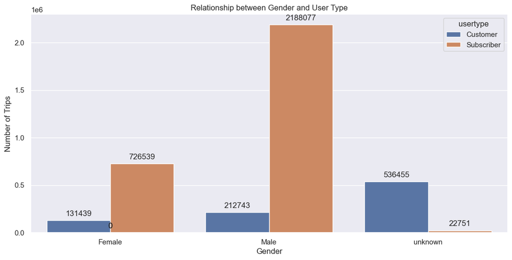

```python
plt.figure(figsize=(13, 6))
barplot = sns.barplot(data = sdf, x = 'gender', y = 'trip_id', hue = 'usertype')

for p in barplot.patches:
    barplot.annotate(format(p.get_height(), '.0f'),
                     (p.get_x() + p.get_width() / 2., p.get_height()),
                     ha = 'center', va = 'center', xytext = (0, 10),
                     textcoords = 'offset points')

plt.title('Relationship between Gender and User Type')
plt.xlabel('Gender')
plt.ylabel('Number of Trips')

# Salvar as imagens
plt.savefig('gender_x_usertypes')

# Exibir o gráfico
plt.show()
```

### Gender Distribution Analysis

- Of the 3,818,004 trips, trips made by member users represent 76.9 of the trips.
- Male users are responsible for 2,188,077 (74.5%) of trips taken by members.
- While female users are responsible for 726,539 (24.7%) trips.

### Usage Pattern per Month

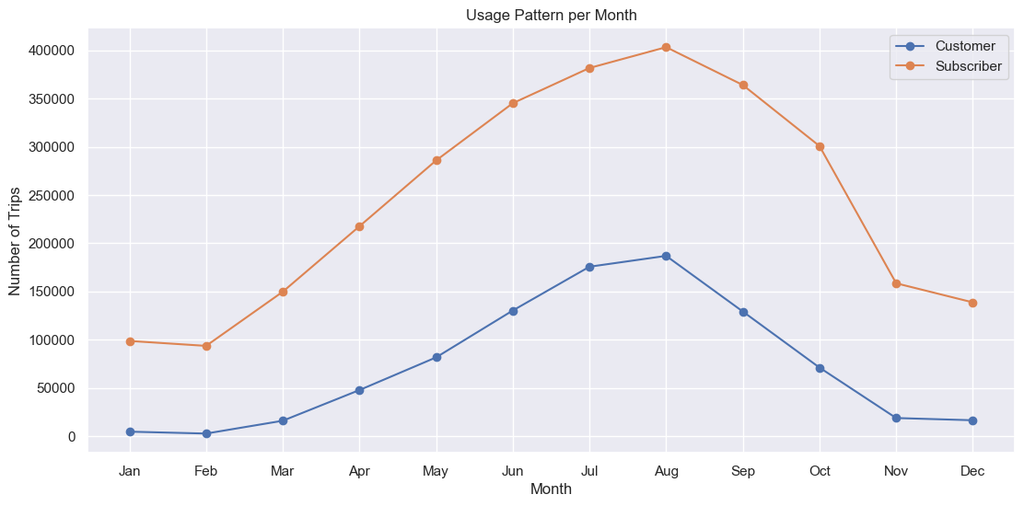

```python
df['start_month'] = df['start_time'].dt.month

casual_data = df[df['usertype'] == 'Customer']
member_data = df[df['usertype'] == 'Subscriber']


casual_monthly_counts = casual_data['start_month'].value_counts().sort_index()
member_monthly_counts = member_data['start_month'].value_counts().sort_index()


plt.figure(figsize=(13, 6))
plt.plot(casual_monthly_counts.index, casual_monthly_counts.values, marker='o', label='Customer')
plt.plot(member_monthly_counts.index, member_monthly_counts.values, marker='o', label='Subscriber')
plt.title('Usage Pattern per Month')
plt.xlabel('Month')
plt.ylabel('Number of Trips')
plt.xticks(casual_monthly_counts.index, labels=['Jan', 'Feb', 'Mar', 'Apr', 'May', 'Jun', 'Jul', 'Aug', 'Sep', 'Oct', 'Nov', 'Dec'])
plt.legend()
plt.grid(True)
plt.show()
```

### Usage Pattern Throughout the Year

- Possible influence of adverse weather conditions, such as intense cold.